# Dota 2 Analysis

By: Chip Hennig, Kyle Rodrigues, Joe Weller

# Introduction

In this notebook, we take a deep dive into a [Dota 2 Dataset](https://www.kaggle.com/devinanzelmo/dota-2-matches). Dota 2 is a 5 on 5 multiplayer video game with one team being the radiant and the other team being the dire. This dataset includes many CSV files that covers the matches, chat, and statistics of the players on both teams.

# Hypotheses

We created four different hypotheses to test:

1. The number of times players chose items and heroes follow a normal distribution over the course of multiple games.
2. A team’s hero and item composition can produce optimal trends for total team effectiveness.
3. It’s possible to reliably engineer an MVP feature for the player which contributed the most.
4. The MVP score calculation can correlate with the player’s chance of winning.

# Data Set

## Getting Data Set

After downloading the dataset from Kaggle, lets get the data and set path of the files.

```r
# file location
files <- list.files(path = "data")
path <- "C:/Users/wellerj/Downloads/data/"

# Set path of files
counter <- 1
for (file in files) {
  files[counter] <- paste(path, file, sep = "")
  counter <- counter + 1
}
```

Now lets create tibble of the files we are interested in to hold the data in. Notice how we add in rows for missing heros and seasonal/unknown items that can’t be found in our dataset. Additionally, we clean up the players tibble so that it just includes the match id, the hero id, and the items of each hero.

```r
# Create tibble of each files
heros <- read_csv(files[1], show_col_types = FALSE) %>%
  select(-starts_with("name"))
heros <- add_row(heros, hero_id=0, localized_name="No_Hero")

items <- read_csv(files[2], show_col_types = FALSE)

# Add no item value
items <- add_row(items, item_id=0, item_name="no_item")

# Fill in missing values for seasonal/unknown items (like patched out neutrals)
t <- seq.int(0, 266)
t <- as_tibble(t)
t <- rename(t, item_id=value)

items <- t %>%
  full_join(items, by="item_id")
items <- items %>% replace(is.na(.), "unknown_item")

matches <- read_csv(files[3], show_col_types = FALSE)

player_time <- read_csv(files[4], show_col_types = FALSE)

players <- read_csv(files[5], show_col_types = FALSE)

# players now only have match id, hero id and items
players <- players %>%
  select(-c(4:17)) %>%
  select(-c(2)) %>%
  select(c(1:8))
```

# Data Preprocessing

## Data Cleaning

Using players, matches, heros and items, lets clean up our dataset a bit more by replacing hero id and item ids with their actual names.

```r
# Replace hero_id with the localized_name of the hero
players <- players %>%
  inner_join(heros, by = "hero_id") %>%
  select(-starts_with("hero_id"))

# Replace item_id with item_name of the item
items <- rename(items, item_0=item_id)
items <- rename(items, item0=item_name)

players <- players %>%
  inner_join(items, by = "item_0") %>%
  select(-starts_with("item_0"))

items <- rename(items, item_1=item_0)
items <- rename(items, item1=item0)

players <- players %>%
  inner_join(items, by = "item_1") %>%
  select(-starts_with("item_1"))

items <- rename(items, item_2=item_1)
items <- rename(items, item2=item1)

players <- players %>%
  inner_join(items, by = "item_2") %>%
  select(-starts_with("item_2"))

items <- rename(items, item_3=item_2)
items <- rename(items, item3=item2)

players <- players %>%
  inner_join(items, by = "item_3") %>%
  select(-starts_with("item_3"))

items <- rename(items, item_4=item_3)
items <- rename(items, item4=item3)

players <- players %>%
  inner_join(items, by = "item_4") %>%
  select(-starts_with("item_4"))

items <- rename(items, item_5=item_4)
items <- rename(items, item5=item4)

players <- players %>%
  inner_join(items, by = "item_5") %>%
  select(-starts_with("item_5"))

players <- rename(players, name=localized_name)

# Reset items tibble
items <- read_csv(files[2], show_col_types = FALSE)

# Add no item value
items <- add_row(items, item_id=0, item_name="no_item")

# Fill in missing values for seasonal/unknown items (like patched out neutrals)
t <- seq.int(0, 266)
t <- as_tibble(t)
t <- rename(t, item_id=value)

items <- t %>%
  full_join(items, by="item_id")
items <- items %>% replace(is.na(.), "unknown_item")

print(players)
```

## Dummy Variables

Now lets convert our dataset to dummy variables where we essentially have a column for each hero and item for each team. The heros will be catagorical variables while the items will not be categorical because they would need to be separated by each player and that would exapand out the dataset too much, so instead we just summarize the amount of times players on a team bought that item.

```r
heros <- rename(heros, dire=localized_name)
heros <- dummy_cols(heros, select_columns = 'dire')
heros <- rename(heros, radiant=dire)
heros <- dummy_cols(heros, select_columns = 'radiant', remove_selected_columns = TRUE)
heros <- heros %>%
  select(-c(1))

hero_colnames = colnames(heros)

items <- items %>%
  select(-c(1))

items <- rename(items, dire=item_name)
items <- dummy_cols(items, select_columns = 'dire')
items <- rename(items, radiant=dire)
items <- dummy_cols(items, select_columns = 'radiant', remove_selected_columns = TRUE)

item_colnames = colnames(items)
item_colnames <- append(item_colnames, "dire_NA")
item_colnames <- append(item_colnames, "radiant_NA")
# Likely convert item names to a dummy variable using spread() method

col_names <- append(hero_colnames, item_colnames)
```

## Organize Data By Category

This is how we organized our data. This part of the code is only run once, and uploads a csv with the final dataset since it can take 7-9 hours to run due to lack of vectorization (couldn’t figure out how to do it). It basically parses through the players, groups by match id and inputs heros/items into a new tibble following the dummy variables format.

```r
end_len <- ((nrow(players) - 1)/10) + 1
print(end_len)
data_2 <- setNames(data.frame(matrix(ncol = 610, nrow = 0)), col_names)
data_2 <- as_tibble(data_2)
data_2
for(index in 1:end_len) {
  # add heros
  test = c("t" = 0)
  test = data.frame(test)
  test = t(test)
  test = as_tibble(test)
  for (i in 1:10) {
    hero_name = ""
    if (i <= 5) {
      hero_name = paste0("radiant_", players[i, "name"])
    } else {
      hero_name = paste0("dire_", players[i, "name"])
    }
    if(hero_name %in% colnames(test)) {
      test[hero_name] = test[hero_name] + 1
    } else {
      test[hero_name] = 1
    }
  }

  # add items
  for (r in 1:10) {
    for (c in 3:8) {
      item_name = ""
      if (r <= 5) {
        item_name = paste0("radiant_", players[r, c])
      } else {
        item_name = paste0("dire_", players[r, c])
      }
      if(item_name %in% colnames(test)) {
        test[item_name] = test[item_name] + 1
      } else {
        test[item_name] = 1
      }
    }
  }

  #test = as_data_frame(test)
  result = tryCatch(
    expr = {
      data_2 <- add_row(data_2, test[-1])
    },
    error = function(e) {
      print(e)
      print(index)
      print(test)
    }
  )
  # data_2 <- add_row(data_2, test[-1])
  data_2 <- data_2 %>% replace(is.na(.), 0)

  # Delete rows in original players tibble
  players <- players[-c(1:10),]
}
  write.csv(data_2, file = "final_data_updated.csv", row.names = FALSE)
```

## Imported Data from Organize Step

Assuming that we have the data from the previous step, this imports that data from the file and displays it.

```r
data_2 = read_csv("final_data_updated.csv")
print(data_2)
```

```
## # A tibble: 50,000 x 610
##    dire_Abaddon dire_Alchemist `dire_Ancient Apparition` `dire_Anti-Mage`
##           <dbl>          <dbl>                     <dbl>            <dbl>
##  1            1              1                         0                0
##  2            0              1                         0                0
##  3            0              0                         0                0
##  4            0              0                         0                0
##  5            0              0                         0                0
##  6            0              0                         0                0
##  7            1              0                         0                0
##  8            0              0                         0                0
##  9            0              0                         0                0
## 10            0              0                         0                0
## # ... with 49,990 more rows, and 606 more variables: dire_Arc Warden <dbl>,
## #   dire_Axe <dbl>, dire_Bane <dbl>, dire_Batrider <dbl>,
## #   dire_Beastmaster <dbl>, dire_Bloodseeker <dbl>, dire_Bounty Hunter <dbl>,
## #   dire_Brewmaster <dbl>, dire_Bristleback <dbl>, dire_Broodmother <dbl>,
## #   dire_Centaur Warrunner <dbl>, dire_Chaos Knight <dbl>, dire_Chen <dbl>,
## #   dire_Clinkz <dbl>, dire_Clockwerk <dbl>, dire_Crystal Maiden <dbl>,
## #   dire_Dark Seer <dbl>, dire_Dazzle <dbl>, dire_Death Prophet <dbl>, ...
```

## MVP Feature Engineering

Creation of the MVP feature (which player contributed the most on each team per match).

```r
players = read_csv("data/players.csv")
matches = read_csv("data/match.csv")
calc_mvp_score = function(kills, deaths, assists, denies, damage, healing, level) {
  return((kills*10)-(deaths*5)+(assists*7)+(denies*3)+(damage*0.005)+(healing*0.01)+(level*5))
}

players$MVP = FALSE
team = c()
for(index in 1:100) {
  player = players[index,]
  mvp_score = calc_mvp_score(player$kills, player$deaths, player$assists, player$denies,
                             player$hero_damage, player$hero_healing, player$level)
  team = append(team, mvp_score)
  if (index %% 5 == 0) {
    highest = 0
    highest_index = 1
    for (player_index in 1:5){
      if (team[player_index] > highest) {
        highest = team[player_index]
        highest_index = player_index
      }
    }
    players[index-5+highest_index,]$MVP = TRUE
    team = c()
  }
}
print(players)
```

```
## # A tibble: 500,000 x 74
##    match_id account_id hero_id player_slot  gold gold_spent gold_per_min
##       <dbl>      <dbl>   <dbl>       <dbl> <dbl>      <dbl>        <dbl>
##  1        0          0      86           0  3261      10960          347
##  2        0          1      51           1  2954      17760          494
##  3        0          0      83           2   110      12195          350
##  4        0          2      11           3  1179      22505          599
##  5        0          3      67           4  3307      23825          613
##  6        0          4     106         128   476      12285          397
##  7        0          0     102         129   317      10355          303
##  8        0          5      46         130  2390      13395          452
##  9        0          0       7         131   475       5035          189
## 10        0          6      73         132    60      17550          496
## # ... with 499,990 more rows, and 67 more variables: xp_per_min <dbl>,
## #   kills <dbl>, deaths <dbl>, assists <dbl>, denies <dbl>, last_hits <dbl>,
## #   stuns <chr>, hero_damage <dbl>, hero_healing <dbl>, tower_damage <dbl>,
## #   item_0 <dbl>, item_1 <dbl>, item_2 <dbl>, item_3 <dbl>, item_4 <dbl>,
## #   item_5 <dbl>, level <dbl>, leaver_status <dbl>, xp_hero <dbl>,
## #   xp_creep <dbl>, xp_roshan <dbl>, xp_other <dbl>, gold_other <dbl>,
## #   gold_death <dbl>, gold_buyback <dbl>, gold_abandon <dbl>, ...
```

# Data Analysis and Visualization

## Character Analysis

Analyzing the most and least popular characters over 50k games as well as seeing if the character selection over 50k games follow a normal distribution.

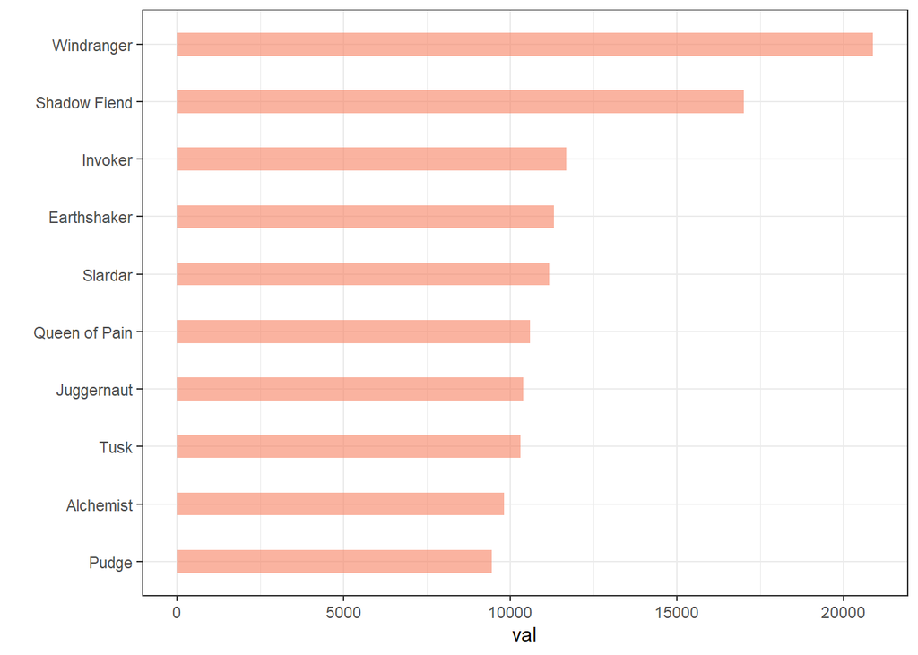

```r
dire_data = data_2[1:113]
radiant_data = data_2[114:226]
total_dire_data = colSums(dire_data)
total_radiant_data = colSums(radiant_data)
total_data = c(total_dire_data, total_radiant_data)
names(total_data) = mgsub(names(total_data),c("dire_", "radiant_"), c("", ""))
total_hero_data = tapply(total_data, names(total_data), sum)
total_hero_df = data.frame(name=names(total_hero_data), val=unname(total_hero_data))

top_n(total_hero_df, n=10, val)  %>%
  mutate(name = fct_reorder(name, val)) %>%
  ggplot( aes(x=name, y=val)) +
    geom_bar(stat="identity", fill="#f68060", alpha=.6, width=.4) +
    coord_flip() +
    xlab("") +
    theme_bw()
```

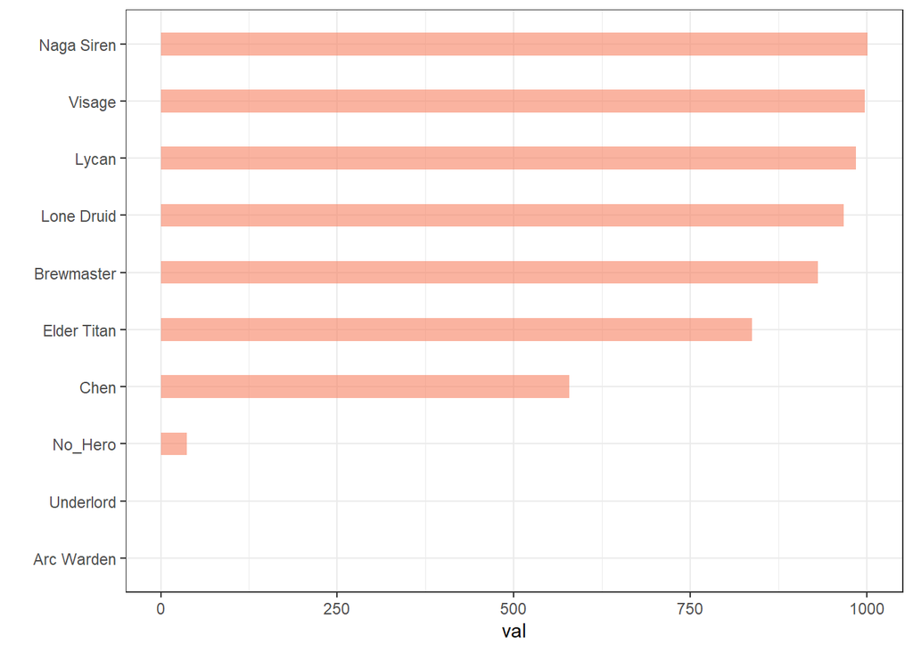

```r
top_n(total_hero_df, n=-10, val)  %>%
  mutate(name = fct_reorder(name, val)) %>%
  ggplot( aes(x=name, y=val)) +
    geom_bar(stat="identity", fill="#f68060", alpha=.6, width=.4) +
    coord_flip() +
    xlab("") +
    theme_bw()
```

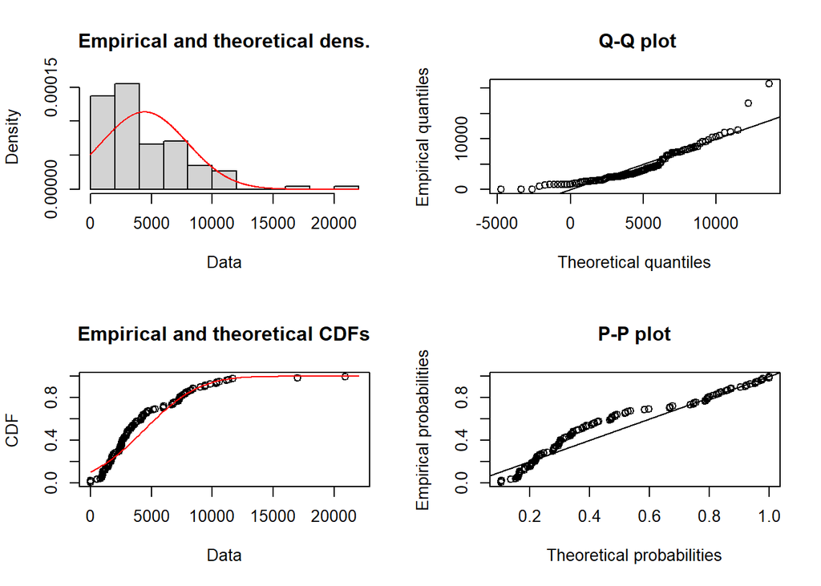

```r
FIT = fitdist(as.numeric(total_hero_df$val), "norm")
plot(FIT)
```

## Item Analysis

Analyzing the most and least popular items over 50k games as well as seeing if the item selection over 50k games follow a normal distribution.

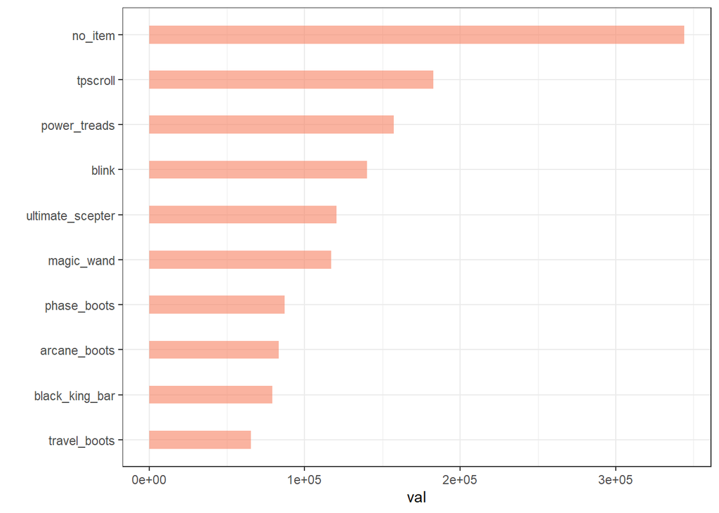

```r
dire_item_data = data_2[227:417]
radiant_item_data = data_2[415:610]
total_dire_item_data = colSums(dire_item_data)
total_radiant_item_data = colSums(radiant_item_data)
total_item_data = c(total_dire_item_data, total_radiant_item_data)
names(total_item_data) = mgsub(names(total_item_data),c("dire_", "radiant_"), c("", ""))
total_item_data = tapply(total_item_data, names(total_item_data), sum)
total_item_df = data.frame(name=names(total_item_data), val=unname(total_item_data))

top_n(total_item_df, n=10, val)  %>%
  mutate(name = fct_reorder(name, val)) %>%
  ggplot( aes(x=name, y=val)) +
    geom_bar(stat="identity", fill="#f68060", alpha=.6, width=.4) +
    coord_flip() +
    xlab("") +
    theme_bw()
```

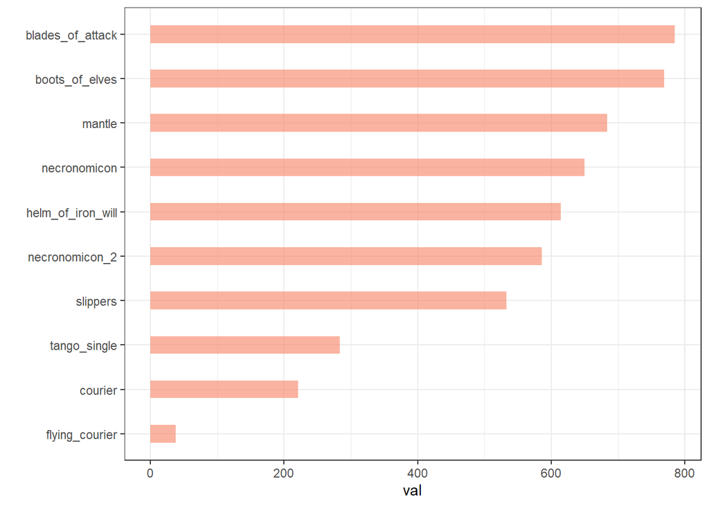

```r
total_item_df[total_item_df==0] = 1000
top_n(total_item_df, n=-10, val)  %>%
  mutate(name = fct_reorder(name, val)) %>%
  ggplot( aes(x=name, y=val)) +
    geom_bar(stat="identity", fill="#f68060", alpha=.6, width=.4) +
    coord_flip() +
    xlab("") +
    theme_bw()
```

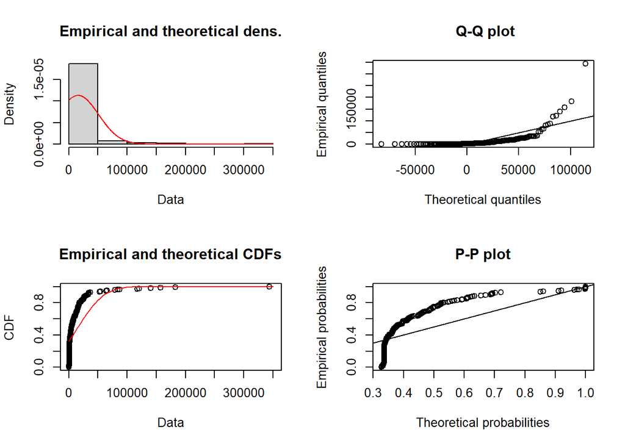

```r
FIT = fitdist(as.numeric(total_item_df$val), "norm")
plot(FIT)
```

## Determine whether or not a player won the match

```r
players = inner_join(matches[c("match_id", "radiant_win")], players)
# Row indexing from: https://stackoverflow.com/questions/32078578/how-to-group-by-every-7-rows-and-aggregate-those-7-values-by-median
players["team_index"] = mod(c(0, rep(1:(nrow(players)-1)%/%5)), 2)
players["did_win"] = players %>%
  transmute(did_win = ifelse(team_index==1, !radiant_win, radiant_win))
players[c("team_index", "radiant_win", "did_win")]
```

```
## # A tibble: 500,000 x 3
##    team_index radiant_win did_win
##         <dbl> <lgl>       <lgl>
##  1          0 TRUE        TRUE
##  2          0 TRUE        TRUE
##  3          0 TRUE        TRUE
##  4          0 TRUE        TRUE
##  5          0 TRUE        TRUE
##  6          1 TRUE        FALSE
##  7          1 TRUE        FALSE
##  8          1 TRUE        FALSE
##  9          1 TRUE        FALSE
## 10          1 TRUE        FALSE
## # ... with 499,990 more rows
```

## Compile tibble of relevent stats

```r
calc_mvp_score = function(kills, deaths, assists, denies, damage, healing, level) {
  return((kills*10)-(deaths*5)+(assists*7)+(denies*3)+(damage*0.005)+(healing*0.01)+(level*5))
}
players["mvp_score"] = players %>%
  transmute(mvp_score = calc_mvp_score(kills, deaths, assists, denies, hero_damage, hero_healing, level))
players["mvp_score"]
```

```
## # A tibble: 500,000 x 1
##    mvp_score
##        <dbl>
##  1     330.
##  2     497.
##  3     210.
##  4     417.
##  5     634.
##  6     240.
##  7     179.
##  8     281.
##  9      79.9
## 10     122.
## # ... with 499,990 more rows
```

## Statiscal significance of in-game stats to chance of victory

```r
kruskal.test(formula(kills ~ did_win), players)
```

```
##
##  Kruskal-Wallis rank sum test
##
## data:  kills by did_win
## Kruskal-Wallis chi-squared = 42997, df = 1, p-value < 2.2e-16
```

```r
kruskal.test(formula(hero_damage ~ did_win), players)
```

```
##
##  Kruskal-Wallis rank sum test
##
## data:  hero_damage by did_win
## Kruskal-Wallis chi-squared = 22449, df = 1, p-value < 2.2e-16
```

```r
kruskal.test(formula(level ~ did_win), players)
```

```
##
##  Kruskal-Wallis rank sum test
##
## data:  level by did_win
## Kruskal-Wallis chi-squared = 32391, df = 1, p-value < 2.2e-16
```

```r
kruskal.test(formula(mvp_score ~ did_win), players)
```

```
##
##  Kruskal-Wallis rank sum test
##
## data:  mvp_score by did_win
## Kruskal-Wallis chi-squared = 91382, df = 1, p-value < 2.2e-16
```

# Data Modeling and Prediction

## Train Logistic Regression function using the MVP score for to chance of victory

```r
# Train-test split
ind = sample(2, nrow(players), replace = TRUE, prob = c(.75,.25))
mvp_train = players[ind==1,]
mvp_test = players[ind==2,]

# Log regression
model = glm(did_win~mvp_score, mvp_train, family="binomial")
pred = predict(model, mvp_test, type='response')
table(mvp_test$did_win, pred > 0.5)
```

```
##
##         FALSE  TRUE
##   FALSE 43678 18484
##   TRUE  21717 40460
```

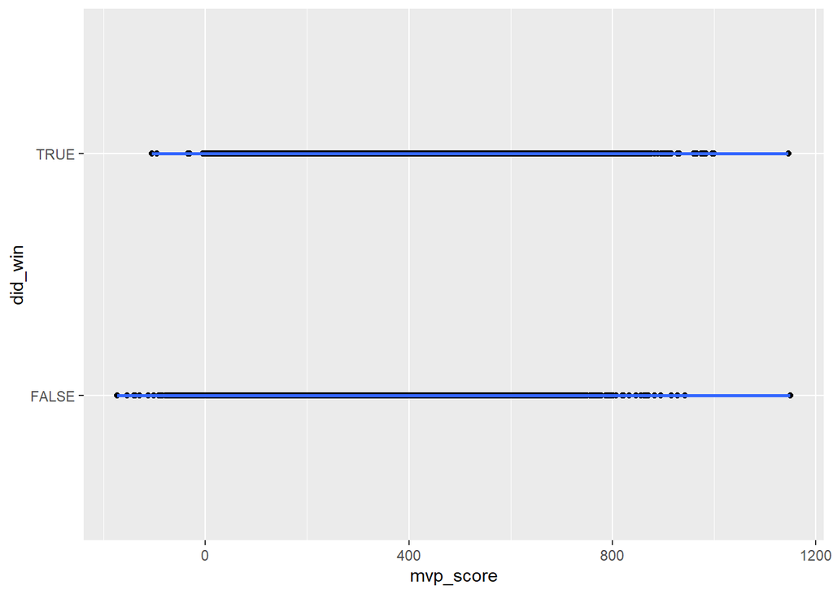

```r
ggplot(mvp_train, aes(x=mvp_score, y=did_win)) + geom_point() +
stat_smooth(method="glm", family="binomial", se=FALSE)
```

## Team Composition / Item Selection Random Forest

Using the random forest model to predict which team will win based on their team composition and item selection.

```r
match = read_csv("data/match.csv")
# Character data pre-processing
hero_data = data_2[1:226]
hero_data = lapply(hero_data, as.factor)
hero_data = data.frame(hero_data)
data_items = data_2[227:610]
data = cbind(hero_data, data_items)
data$win = as.factor(match$radiant_win)

# Train-test split
ind = sample(2, nrow(data), replace = TRUE, prob = c(.75,.25))
train = data[ind==1,]
test = data[ind==2,]

# Random forest on heroes
rf = randomForest(win~., data = train, ntree = 25)
pred = predict(rf, test)
confusionMatrix(pred, test$win)
```

```
## Confusion Matrix and Statistics
##
##           Reference
## Prediction FALSE TRUE
##      FALSE  5655  473
##      TRUE    394 6025
##
##                Accuracy : 0.9309
##                  95% CI : (0.9263, 0.9353)
##     No Information Rate : 0.5179
##     P-Value [Acc > NIR] : < 2.2e-16
##
##                   Kappa : 0.8617
##
##  Mcnemar's Test P-Value : 0.008073
##
##             Sensitivity : 0.9349
##             Specificity : 0.9272
##          Pos Pred Value : 0.9228
##          Neg Pred Value : 0.9386
##              Prevalence : 0.4821
##          Detection Rate : 0.4507
##    Detection Prevalence : 0.4884
##       Balanced Accuracy : 0.9310
##
##        'Positive' Class : FALSE
##
```

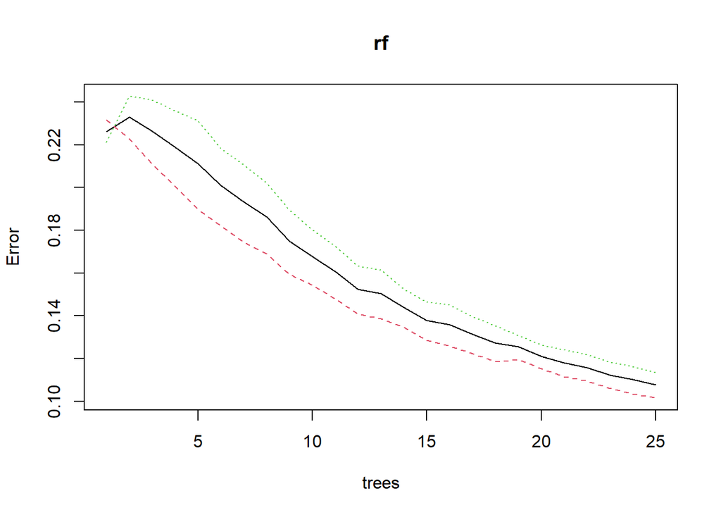

```r
plot(rf)
```

# Results Analysis

## Future Improvements

1. Incorporating the gold and experience metrics into our predictive models.
2. Implementing a regression over time model to predict which team is more likely to win the game in real time.
3. Further optimize the MVP feature to more reliably select the players which contributed the most during matches.
4. Tune the hyper-parameters of the random forest model to further increase its performance.
5. Use sentiment analysis on the chat data to determine whether negativity of players correlates to win probability.